# Using the Manifesto Corpus with quanteda

Nicolas Merz nicolas.merz@wzb.eu

19 June 2018

In this tutorial, we will show how to use the quanteda package to analyze the Manifesto Corpus. We assume that you have already read [First steps with manifestoR](https://manifesto-project.wzb.eu/tutorials/firststepsmanifestoR) (at least until “Downloading documents from the Manifesto Corpus”) and that you are familiar with the [pipe %>% operator](http://magrittr.tidyverse.org/).

# Grammar and logic of quanteda

[Quanteda (Benoit et al. 2018)](https://quanteda.io/) is a comprehensive powerful text analysis R package. It is [well](https://tutorials.quanteda.io) [documented](http://docs.quanteda.io/reference/), [fast](https://quanteda.io/performance/) and [versatile](http://docs.quanteda.io/articles/pkgdown/comparison.html).

Quanteda has three main objects.

- Corpora (created with the `corpus()`). These contain the texts() and document meta information in form of `docvars()`.
- tokens objects (created with `tokens()`). The `tokens` function tokenizes corpora into tokens. Tokens can be of different kind, such as words, paragraphs, or ngrams.
- Document-feature matrices (created with `dfm()`). `dfm`s are matrices where each row represents one document. Columns represent features (mostly tokens) and cells contain information about the occurence of features within documents. Features are mostly tokens (eg words or n-grams). `dfm` is the starting point for most types of analyses that draw inferences from the frequency of tokens.

Most quanteda functions take on of these three as an input and somehow transform it. The functions are consistently and intuitively named, eg. `dfm_group` groups a document-feature matrix, `tokens_remove` removes tokens from a tokens object, etc.

# manifestoR and Quanteda

We first use the usual “header” of a manifestoR script: loading packages, setting the api-key and fixing the corpus version (to ensure reproducibility).

```r
library(manifestoR)
library(quanteda)
library(dplyr)
library(ggplot2)
library(tidyr)
library(stringr)

mp_setapikey(key.file="manifesto_apikey.txt")
mp_use_corpus_version("2017-2")
```

Before working with the Manifesto Corpus with Quanteda, it is important to think about the level of analysis (level of aggregation). Many operations on Quanteda are meant to happen on the document level. For example documents have metalevel information, while a smaller unit cannot have separate meta-information. Different documents however can have the same meta information (for example the party code or the same language). Depending on the research question it might sometimes be more appropriate to treat manifestos as documents and in other cases it might be better to treat individual quasi-sentences as documents.

Quanteda can directly import corpora from the manifestoR corpus format applying the `corpus` function to a normal `ManifestoCorpus` object that one can get with the `mp_corpus` function (which is a kind of `tm` corpus, see the First Steps with manifestoR tutorial). We use `mp_availability` to check the availability of documents for the 2012 US elections. We save the object and use it as input for the `mp_corpus` function. Alternatively, we could have also used the same expression for `mp_corpus` that we used for `mp_availability`.

```r
available_us2012 <- mp_availability(countryname == "United States" & date == 201211 & partyname %in% c("Democratic Party","Republican Party"))
```

```
## Connecting to Manifesto Project DB API... corpus version: 2017-2
```

```r
available_us2012
```

```
##           Queried for        Corpus Version       Documents found
##                     2                2017-2              2 (100%)
## Coded Documents found       Originals found             Languages
##              2 (100%)              2 (100%)           1 (english)
```

```r
tm_corpus <- mp_corpus(available_us2012)
```

```
## Connecting to Manifesto Project DB API... corpus version: 2017-2
```

```r
tm_corpus
```

```
## <<ManifestoCorpus>>
## Metadata:  corpus specific: 0, document level (indexed): 0
## Content:  documents: 2
```

We queried for two documents of which both are “Coded document” - documents with annotations. When converting this to a Quanteda corpus, however this results in 3188 documents as every quasi-sentence is considered an individual document.

```r
quanteda_corpus <- corpus(tm_corpus) ## quanteda's corpus function
quanteda_corpus
```

```
## Corpus consisting of 3,188 documents and 18 docvars.
```

The meta data information from the Manifesto Corpus is stored in the docvars and is available for each quasi-sentence.

```r
quanteda_corpus %>% docvars() %>% names()
```

```
##  [1] "cmp_code"                    "eu_code"
##  [3] "manifesto_id"                "party"
##  [5] "date"                        "language"
##  [7] "source"                      "has_eu_code"
##  [9] "is_primary_doc"              "may_contradict_core_dataset"
## [11] "md5sum_text"                 "url_original"
## [13] "md5sum_original"             "annotations"
## [15] "handbook"                    "is_copy_of"
## [17] "title"                       "id"
```

When using manifestos that were coded with different versions of the coding instructions (see the tutorial on subcategories), it might be a good idea to first recode version 5 codes to version 4 using manifestoR `recode_v5_to_v4` function before transforming it into the quanteda corpus format.

```r
mp_corpus(countryname == "Germany" & date == 201709) %>%
  corpus %>%
  docvars(field = "cmp_code") %>%
  head(10)
```

```
##  [1] "H"     "0"     "202.1" "201.1" "503"   "201.1" "503"   "201.1"
##  [9] "201.1" "501"
```

```r
mp_corpus(countryname == "Germany" & date == 201709) %>%
  recode_v5_to_v4() %>%
  corpus %>%
  docvars(field = "cmp_code") %>%
  head(10)
```

```
##  [1] "H"   "0"   "202" "201" "503" "201" "503" "201" "201" "501"
```

```r
us_not_annotated <- mp_availability(countryname == "United States" & date %in% c(200011))
```

```
## Connecting to Manifesto Project DB API... corpus version: 2017-2
```

```r
us_not_annotated
```

```
##           Queried for        Corpus Version       Documents found
##                     2                2017-2              2 (100%)
## Coded Documents found       Originals found             Languages
##                0 (0%)              2 (100%)           1 (english)
```

```r
mp_corpus(us_not_annotated) %>% corpus()
```

```
## Connecting to Manifesto Project DB API... corpus version: 2017-2
```

```
## Corpus consisting of 2 documents and 18 docvars.
```

If you want to use a set of manifestos where one part of the set is available as annotated and the other as non-annotated documents, it might be reasonable to first transform them to a similar aggregation level. One possibility would be to separately download the non-annotated manifestos and segment them using `corpus_segment()` into sentences and then combine them with a corpus that is already parsed into quasi-sentences. If the level of analysis is anyway the manifesto level, then one can also later group the document-feature matrix based on the manifesto id using `dfm_group`.

# Subsetting the corpus

Quanteda can easily subset the corpus based on document level variables. The following code snippets subset the corpus based on the party code or based on the cmp_code.

```r
quanteda_corpus %>% corpus_subset(party == 61620) %>% texts() %>% head(5)
```

```
##                                                                             61620_201211.1
##                                                                    "We Believe in America"
##                                                                             61620_201211.2
##                          "This platform is dedicated with appreciation and reverence for:"
##                                                                             61620_201211.3
##                                                                                 "Preamble"
##                                                                             61620_201211.4
## "The 2012 Republican Platform is a statement of who we are and what we believe as a Party"
##                                                                             61620_201211.5
##                                         "and our vision for a stronger and freer America."
```

```r
quanteda_corpus %>% corpus_subset(cmp_code == 501) %>% texts() %>% head(5)
```

```
##                                                                                                                       61320_201211.87
##                                                                                         "and fuel-efficiency standards are doubling."
##                                                                                                                      61320_201211.295
##                    "Historic investments in clean energy technologies have helped double the electricity we get from wind and solar."
##                                                                                                                      61320_201211.296
##                                             "New emissions and fuel efficiency standards for American cars are reducing our oil use,"
##                                                                                                                      61320_201211.308
## "which is why the Obama administration has proposed a number of safeguards to protect against water contamination and air pollution."
##                                                                                                                      61320_201211.309
##                                                                 "We will continue to advocate for the use of this clean fossil fuel,"
```

# Tokenization with `tokens()`

The `tokens()` function in quanteda tokenizes the documents. Tokens can be words, characters, sentences or ngrams. The function provides many arguments to facilitate the cleaning and preprocessing.

```r
quanteda_corpus %>% tokens(what = "word") %>% head(2)
```

```
## tokens from 2 documents.
## 61320_201211.1 :
## [1] "Moving"     "America"    "Forward"    "2012"       "Democratic"
## [6] "National"   "Platform"
##
## 61320_201211.2 :
## [1] "Moving"  "America" "Forward"
```

One could also tokenize the same document into bi-grams using the ngram argument. By using ngrams = 1:2, quanteda tokenizes into uni-grams and bi-grams.

```r
quanteda_corpus %>% tokens(ngram = 1:2) %>% head(2)
```

```
## tokens from 2 documents.
## 61320_201211.1 :
##  [1] "Moving"              "America"             "Forward"
##  [4] "2012"                "Democratic"          "National"
##  [7] "Platform"            "Moving_America"      "America_Forward"
## [10] "Forward_2012"        "2012_Democratic"     "Democratic_National"
## [13] "National_Platform"
##
## 61320_201211.2 :
## [1] "Moving"          "America"         "Forward"         "Moving_America"
## [5] "America_Forward"
```

Tokenization is particularly important for pre-processing and cleaning the texts. One can easily remove nubmers, punctuation or stopwords. Moreover, it is simple to transform all text to lower case or stem words.

```r
quanteda_corpus %>% tokens(what = "word", remove_punct = TRUE, remove_numbers = TRUE) %>%
  tokens_tolower() %>%
  tokens_remove(stopwords("english")) %>%
  tokens_wordstem() %>%
  head(4)
```

```
## tokens from 4 documents.
## 61320_201211.1 :
## [1] "move"     "america"  "forward"  "democrat" "nation"   "platform"
##
## 61320_201211.2 :
## [1] "move"    "america" "forward"
##
## 61320_201211.3 :
##  [1] "four"       "year"       "ago"        "democrat"   "independ"
##  [6] "mani"       "republican" "came"       "togeth"     "american"
## [11] "move"       "countri"    "forward"
##
## 61320_201211.4 :
## [1] "midst"    "greatest" "econom"   "crisi"    "sinc"     "great"
## [7] "depress"
```

# Constructing a document-feature-matrix with `dfm`

The construction of a document feature matrix is at the core of most automatic text analyses workflows. `dfm` is quanteda’s powerful command to construct a document-feature matrix. In many cases, one can skip the step to generate `tokens` from a corpus, but directly use `dfm` on a corpus as the dfm command passes on most arguments to `tokens`. To get a “standard” preprocessed document feature matrix with lower casing, removed punctuation and numbers as well as stemmed words from a corpus, one would add the following arguments to dfm:

```r
quanteda_corpus %>% dfm(
  tolower = TRUE,
  stem = TRUE,
  remove = stopwords("english"),
  remove_punct = TRUE,
  remove_numbers = TRUE
)
```

```
## Document-feature matrix of: 3,188 documents, 4,008 features (99.8% sparse).
```

```r
quanteda_irish <- mp_corpus(countryname=="Ireland" & date == 201602) %>%
  recode_v5_to_v4() %>%
  corpus() %>%
  dfm(tolower=TRUE, remove_punct = TRUE, remove = stopwords("english")) %>%
  dfm_subset(!(cmp_code %in% c("H","","0","000",NA))) %>%
  dfm_group("cmp_code") %>%
  dfm_weight(scheme = "prop") %>%
  dfm_subset(cmp_code %in% c("501","502","301","411"))
```

```
## Connecting to Manifesto Project DB API... corpus version: 2017-2
## Connecting to Manifesto Project DB API... corpus version: 2017-2
```

```r
quanteda_irish
```

```
## Document-feature matrix of: 4 documents, 13,070 features (86.2% sparse).
```

To plot the most frequent terms, we use the `textstat_frequency()` function. It extracts the most frequent terms (here grouped by cmp_code) and converts these summary statistics to a data.frame. Such a data.frame servers as perfect input for a ggplot.

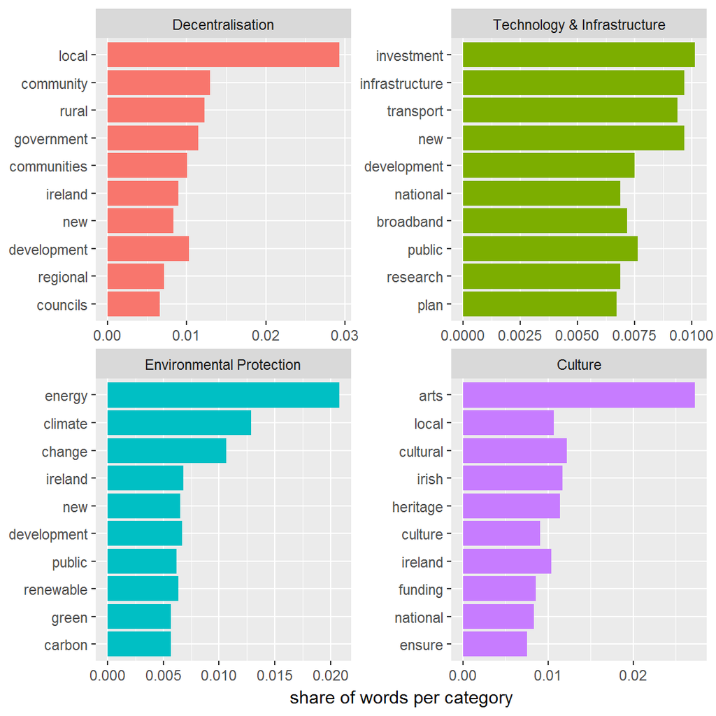

```r
feature_frequencies_categories <- quanteda_irish %>%  textstat_frequency(n = 10, group = "cmp_code")

feature_frequencies_categories %>%
  mutate(cmp_code = factor(group, labels = c("Decentralisation","Technology & Infrastructure","Environmental Protection","Culture"))) %>%
  ggplot(aes(x = reorder(feature, frequency) , y = frequency, fill = cmp_code)) +
  geom_col(show.legend = FALSE) +
  labs(x = NULL, y = "share of words per category") +
  facet_wrap(~cmp_code, ncol = 2, scales = "free") +
  coord_flip()
```

Certainly, similar to tidytext, quanteda also allows the calculation of term-frequency inverse-document frequency (tfidf) scores with `dfm_tfidf`.

# Keyword in context search

Quanteda also provides a nice way to view text passages based on certain key words. The `kwic` (for keyword in context) allows you to use for a text string or pattern. The window indicates how many word around the keyword should be shown in the output. The following is a keyword search for the term “arms” based on the US party platforms.

```r
kwic(quanteda_corpus,phrase("arms"),window = 10) %>%
  DT::datatable(caption="Keywords in context", rownames=FALSE, options = list(scrollX = TRUE,pageLength = 5, lengthMenu = c(5, 10, 15, 20)))
```

| docname | from | to | pre | keyword | post |
| --- | --- | --- | --- | --- | --- |
| 61320_201211.544 | 23 | 23 | welcomed the new flow of special interest money with open | arms | . |
| 61320_201211.816 | 11 | 11 | Firearms . We recognize that the individual right to bear | arms | is an important part of the American tradition , |
| 61320_201211.1033 | 33 | 33 | , President Obama negotiated and signed the landmark New Strategic | Arms | Reduction Treaty with Russia , |
| 61320_201211.1110 | 15 | 15 | accumulated unprecedented wealth and power through the drug trade , | arms | smuggling , human trafficking , and other illicit activities , |
| 61620_201211.542 | 11 | 11 | The Second Amendment : Our Right to Keep and Bear | Arms |  |
| 61620_201211.543 | 11 | 11 | We uphold the right of individuals to keep and bear | arms | , |
| 61620_201211.1054 | 14 | 14 | ensure protection of the fundamental right to keep and bear | arms | , we call on the governing authority to pass laws |
| 61620_201211.1054 | 55 | 55 | , which upheld the fundamental right to keep and bear | arms | for selfdefense . |
| 61620_201211.1499 | 5 | 5 | We will accept no | arms | control agreement that limits our right to selfdefense ; |
| 61620_201211.1595 | 34 | 34 | Rights of Persons with Disabilities , and the U.N . | Arms | Trade Treaty as well as the various declarations from the |

[output cut: 1 more lines]

# Multi-word expressions

Multi-word expressions can pose a problem to automatic text analysis. The expression “New York” stands for something different than the two separate words “new” and “York”. Quanteda offers a simple way to identify such multi-word expressions based on collocations using the `textstat_collocations` function. The following shows an association measure for word pairs. The list contains many expressions that may be better (or even should) be treated as one expression in automatic analysis, such as “United States”, “President Obama”…

```r
quanteda_corpus %>%
  tokens() %>%
  tokens_remove(stopwords("english")) %>%
  textstat_collocations(method = "lambda", size = 2) %>%
  arrange(-lambda) %>%
  top_n(20)
```

```
##                 collocation count count_nested length   lambda        z
## 1           president obama   106            0      2 8.712223 15.83242
## 2              job creation    21            0      2 8.626015 15.41303
## 3          democratic party    51            0      2 7.883312 23.78278
## 4             united states    80            0      2 7.560873 24.57327
## 5           nuclear weapons    18            0      2 7.427154 16.07777
## 6            private sector    26            0      2 7.367855 19.50990
## 7          small businesses    20            0      2 7.315688 18.25340
## 8  current administration's    21            0      2 7.143142 15.40549
## 9              clean energy    22            0      2 7.095694 16.74701
## 10             around world    20            0      2 6.616712 16.98407
## 11          obama democrats    17            0      2 5.898741 15.37824
## 12   current administration    33            0      2 5.767862 22.08521
## 13              health care    30            0      2 5.622307 21.21242
## 14          economic growth    18            0      2 5.519357 16.24574
## 15         health insurance    16            0      2 5.480439 16.15630
## 16        national security    32            0      2 5.091817 21.00124
## 17         obama democratic    22            0      2 5.049483 17.82253
## 18         republican party    18            0      2 4.884566 16.54596
## 19       federal government    31            0      2 4.283170 19.04284
## 20          american people    29            0      2 3.822691 17.06957
```

# Targeted sentiment analysis

Quanteda facilitates dictionary based searchs. The following example illustrates how to conduct a targeted sentiment analysis. We use the corpus created above based on US party platforms of 2012 and tokenize it into words. We then keep only tokens that include the word “President” as well as the ten words before and after every occurence of “President”.

```r
pres_tokens <- tokens(quanteda_corpus) %>%
  tokens_select("President", selection = "keep", window = 10, padding = FALSE, verbose = TRUE)
```

```
## kept 2 features
```

Quanteda has integrated a sentiment dictionary constructed by Young & Soroka (2012) stored in `data_dictionary_LSD2015`. The dictionary contains thousands of positive and negative words or word stems.

```r
data_dictionary_LSD2015[[1]] %>% head(10)
```

```
##  [1] "a lie"     "abandon*"  "abas*"     "abattoir*" "abdicat*"
##  [6] "aberra*"   "abhor*"    "abject*"   "abnormal*" "abolish*"
```

We then use the the sentiment dictionary to count positive and negative words among the surrounding words of “President” to analyze which party speaks more positively or negatively about the president. We “group” by party to get frequencies of positive and negative words aggregated to the party level. The ratio of positive to negative words is much higher for the Democratic Party (61320) than for the Republican Party (61620) when speaking about the “President”. This is little surprising as in 2012, the incumbent President was a Democrat.

```r
pres_dfm <- dfm(pres_tokens, dictionary= data_dictionary_LSD2015[1:2] , group = c("party"))
pres_dfm
```

```
## Document-feature matrix of: 2 documents, 2 features (0% sparse).
## 2 x 2 sparse Matrix of class "dfm"
##        features
## docs    negative positive
##   61320       63      179
##   61620       30       46
```

Quanteda has many more functions. In particular the `textstat_*` functions are powerful and can well applied to manifestos.

# References

Benoit, Kenneth et al. (2018). “quanteda: Quantitative Analysis of Textual Data.”" doi: 10.5281/zenodo.1004683, R package version 1.3.0, http://quanteda.io.

Young, Lori and Stuart Soroka. (2012). “Affective News: The Automated Coding of Sentiment in Political Texts.” Political Communication 29(2): 205-231.